**Regression Examples**

|  | by Prof. Seungchul Lee iSystems Design Lab http://isystems.unist.ac.kr/ UNIST |
| --- | --- |

Table of Contents

# 1. De-noising Signal

We start with a signal represented by a vector $x \in \mathbb{R}^n$. The coefficients $x_i$ correspond to the value of some function of time, evaluated (or *sampled*, in the language of signal processing) at evenly spaced points. It is usually assumed that the signal does not vary too rapidly, which means that usually, we have $x_i \approx x_{i+1}$.

Suppose we have a signal $x$, which does not vary too rapidly and that $x$ is corrupted by some small, rapidly varying noise $v$, i.e. $x_{cor} = x + \upsilon$.

Then if we want to reconstruct $x$ from $x_{cor}$ we should solve (with $\hat{x}$ as the parameter)

$$ \text{minimize} \quad \lVert \hat{x} - x_{cor}\rVert_2 + \lambda\sum_{i=1}^{n-1}(x_{i+1}-x_i)^2 $$

where the parameter $\lambda$ controls the ''smoothnes'' of $\hat{x}$.

Source:

- Boyd & Vandenberghe's book "[Convex Optimization](http://stanford.edu/~boyd/cvxbook/)"
- http://cvxr.com/cvx/examples/ (Figures 6.8-6.10: Quadratic smoothing)
- Week 4 of Linear and Integer Programming by [Coursera](https://www.coursera.org/) of Univ. of Colorado

```python
import numpy as np
import matplotlib.pyplot as plt
import cvxpy as cvx

%matplotlib inline
```

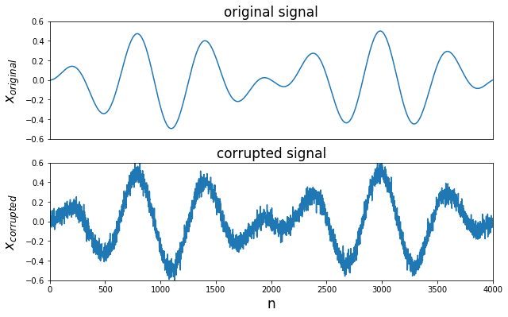

```python
n = 4000
t = np.arange(n).reshape(-1,1)
x = 0.5 * np.sin((2*np.pi/n)*t) * (np.sin(0.01*t))
x_cor = x + 0.05*np.random.randn(n,1)

plt.figure(figsize=(10, 6))
plt.subplot(2,1,1)
plt.plot(t,x,'-')
plt.axis([0, n, -0.6, 0.6])
plt.xticks([])
plt.title('original signal' , fontsize = 17)
plt.ylabel('$x_{original}$', fontsize = 17)

plt.subplot(2,1,2)
plt.plot(t, x_cor,'-')
plt.axis([0, n, -0.6, 0.6])
plt.title('corrupted signal', fontsize = 17)
plt.xlabel('n', fontsize = 17)
plt.ylabel('$x_{corrupted}$', fontsize = 17)
plt.show()
```

## 1.1. Transform de-noising in time into an optimization problem

$$\large \min\limits_{X}\;\left\{\underbrace{\lVert(X - X_{cor})\rVert^2_{2}}_{\text{how much } x \text{ deviates from }x_{cor}} + \mu \underbrace{\sum_{k = 1}^{n-1}(x_{k+1}-x_{k})^2}_{\text{penalize rapid changes of } X}\right\}$$

1) $\min\limits_{X}\;\lVert(X - X_{cor})\rVert^2_{2}$: $\quad$ How much $X$ deviates from $X_{cor}$

2) $\mu\sum\limits_{k = 1}^{n-1}(x_{k+1}-x_{k})^2$: $\quad$ penalize rapid changes of $X$

3) $\mu$ : to adjust the relative weight of 1) & 2)

$$X = \begin{bmatrix} x_{1} \\ x_{2} \\ \vdots \\ x_{n} \end{bmatrix} $$

1) $X - X_{cor} = I_n X - X_{cor}$

2) $\sum\;(x_{k+1}-x_{k})^2 \implies$

$$(x_{2} - x_{1}) - 0 = \begin{bmatrix} -1,&1,&0,&\cdots&0 \end{bmatrix} \begin{bmatrix} x_{1} \\ x_{2} \\ \vdots \\ x_{n} \end{bmatrix}-0 $$$$(x_{3} - x_{2}) - 0 = \begin{bmatrix} 0,&-1,&1,&\cdots&0 \end{bmatrix} \begin{bmatrix} x_{1} \\ x_{2} \\ \vdots \\ x_{n} \end{bmatrix}-0 $$$$ \vdots $$$$\implies \left \Arrowvert \; \begin{bmatrix} -1&1&0&\cdots&0&0 \\ 0&-1&1&\cdots&0&0 \\ \vdots&\vdots&\vdots&\ddots&\vdots&\vdots\\ 0&0&0&\cdots&-1&1 \end{bmatrix} \begin{bmatrix} x_{1} \\ x_{2} \\ \vdots \\ x_{n} \end{bmatrix} - \begin{bmatrix} 0 \\ 0 \\ \vdots \\ 0 \end{bmatrix} \; \right\Arrowvert^2_{2} $$$$\hspace{3.2cm}D \quad\quad\quad\quad\quad\quad X \; \; - \; \; 0 $$

$$\begin{align*} \left\Vert I_n X-X_{cor}\big\Vert^2_{2} + \mu\big\Vert DX-0\right\Vert^2_{2} & = \big\Vert Ax-b\big\Vert^2_{2} \\ & = \Bigg\Vert \begin{bmatrix} I_n\\ \sqrt{\mu}D \end{bmatrix} X- \begin{bmatrix} X_{cor}\\ 0 \end{bmatrix} \Bigg\Vert^2_{2} \end{align*}$$$$ \text{where} \; A = \begin{bmatrix} I_n\\ \sqrt{\mu}D \end{bmatrix},\quad b = \begin{bmatrix} X_{cor}\\ 0 \end{bmatrix} $$

- Then, plug $A$, $b$ into Python with `cvxpy` toolbox to numerically solve

```python
n = 4000
mu = 1000

D = np.zeros([n-1, n])
D[:,0:n-1] -= np.eye(n-1)
D[:,1:n] += np.eye(n-1)
A = np.vstack([np.eye(n), np.sqrt(mu)*D])

b = np.vstack([x_cor, np.zeros([n-1,1])])

A = np.asmatrix(A)
b = np.asmatrix(b)
```

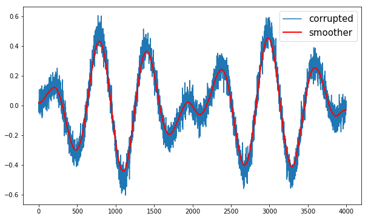

```python
x_reconst = (A.T*A).I*A.T*b

plt.figure(figsize=(10, 6))
plt.plot(t, x_cor, '-', label='corrupted');
plt.plot(t, x_reconst, 'r', label='smoother', linewidth=2)
plt.legend(fontsize=15)
plt.show()
```

## 1.2. with different $\mu$'s (see how $\mu$ affects smoothing results)

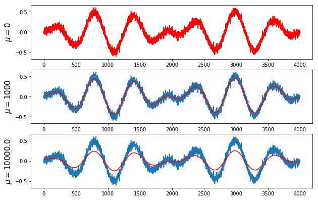

```python
plt.figure(figsize=(10, 9))
mu = [0, 1000, 1e4];

for i in range(len(mu)):
    A = np.vstack([np.eye(n), np.sqrt(mu[i])*D])
    b = np.vstack([x_cor, np.zeros([n-1,1])])

    A = np.asmatrix(A)
    b = np.asmatrix(b)

    x_reconst = (A.T*A).I*A.T*b

    plt.subplot(4,1,i+1)
    plt.plot(t, x_cor, '-')
    plt.plot(t, x_reconst, 'r')
    plt.ylabel('$\mu = {}$'.format(mu[i]), fontsize=15)

plt.show()
```

## 1.3. use CVXPY

- CVXPY strongly encourages to eliminate quadratic forms - that is, functions like `sum_squares`, `sum(square(.))` or `quad_form` - whenever it is possible to construct equivalent models using `norm` instead

$$ \min\; \left\{ \lVert x-x_{cor}\rVert_2^2 + \mu \lVert Dx \rVert_2^2 \right\}$$

```python
n = 4000
mu = 1000

x_reconst = cvx.Variable(n,1)
#obj = cvx.Minimize(cvx.sum_squares(x_reconst-x_cor) + mu*cvx.sum_squares(x_reconst[1:n]-x_reconst[0:n-1]))
obj = cvx.Minimize(cvx.sum_squares(x_reconst-x_cor) + mu*cvx.sum_squares(D*x_reconst))
prob = cvx.Problem(obj).solve('SCS')
```

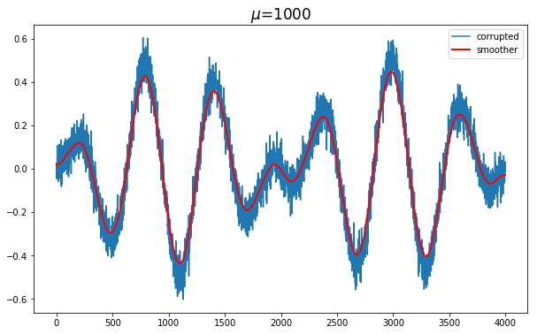

```python
plt.figure(figsize=(10, 6))
plt.plot(t, x_cor)
plt.plot(t, x_reconst.value, 'r', linewidth = 2)
title = '=%s' % str(mu)
plt.title('$\mu$' + title, fontsize = 17)
plt.legend(['corrupted', 'smoother'], loc = 1)
plt.show()
```

[figure not shown]

```python
plt.figure(figsize=(10, 9))

mu = [0, 1000, 1e4]

for i in range(len(mu)):
    x_reconst = cvx.Variable(n,1)
    obj = cvx.Minimize(cvx.sum_squares(x_reconst-x_cor) + mu[i]*cvx.sum_squares(D*x_reconst))
    prob = cvx.Problem(obj).solve('SCS')

    plt.subplot(4,1,i+1)
    plt.plot(t,x_cor,'-')
    plt.plot(t,x_reconst.value,'r')
    plt.ylabel('$\mu = {}$'.format(int(mu[i])), fontsize=15)

plt.show()
```

## 1.4. $L_2$ norm

- CVXPY strongly encourages to eliminate quadratic forms - that is, functions like `sum_squares`, `sum(square(.))` or `quad_form` - whenever it is possible to construct equivalent models using `norm` instead

$$ \min \; \left\{ \lVert x-x_{cor}\rVert_2 + \alpha \lVert Dx ~ \rVert_2 \right \}$$

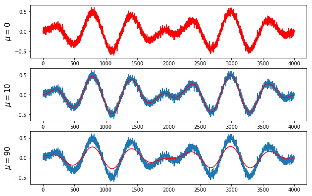

```python
plt.figure(figsize=(10, 9))

alpha = [0, 10, 90]

for i in range(len(alpha)):
    x_reconst = cvx.Variable(n)
    obj = cvx.Minimize(cvx.norm(x_reconst-x_cor, 2) + alpha[i]*(cvx.norm(D*x_reconst, 2)))
    prob = cvx.Problem(obj).solve('SCS')

    plt.subplot(4,1,i+1)
    plt.plot(t,x_cor,'-')
    plt.plot(t,x_reconst.value,'r')
    plt.ylabel('$\mu = {}$'.format(int(alpha[i])), fontsize=15)

plt.show()
```

## 1.5. $L_2$ norm with a constraint

$$\min \; \lVert Dx \rVert_2$$$$ s.t. \quad \lVert x-x_{cor} \rVert_2 < \beta $$

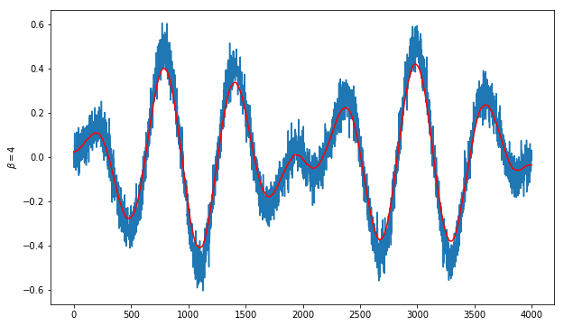

```python
plt.figure(figsize=(10, 6))

beta = 4

x_reconst = cvx.Variable(n)
obj = cvx.Minimize(cvx.norm(D*x_reconst, 2))
const = [cvx.norm(x_reconst-x_cor, 2) <= beta]
prob = cvx.Problem(obj, const).solve(solver='SCS')

plt.plot(t,x_cor,'-')
plt.plot(t,x_reconst.value,'r')
plt.ylabel(r'$\beta = {}$'.format(beta))
plt.show()
```

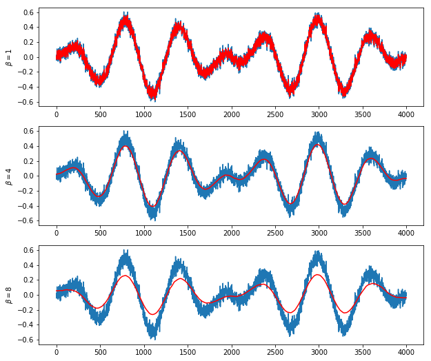

```python
plt.figure(figsize=(10, 9))

beta = [1, 4, 8]

for i in range(len(beta)):

    x_reconst = cvx.Variable(n)
    obj = cvx.Minimize(cvx.norm(x_reconst[1:n] - x_reconst[0:n-1], 2))
    const = [cvx.norm(x_reconst-x_cor, 2) <= beta[i]]
    prob = cvx.Problem(obj, const).solve(solver='SCS')

    plt.subplot(len(beta),1,i+1)
    plt.plot(t,x_cor,'-')
    plt.plot(t,x_reconst.value,'r')
    plt.ylabel(r'$\beta = {}$'.format(int(beta[i])))

plt.show()
```

# 2. Signal with Sharp Transition + Noise

Suppose we have a signal $x$, which is mostly smooth, but has several rapid variations (or jumps). If we apply quadratic smoothing on this signal (see SMOOTHREC_CVX) then in order to remove the noise we will not be able to preserve the signal's sharp transitions.

- First, apply the same method that we used for smoothing signals before
- known as a *total variation problem*
- Source:
  - Chapter 6.3 from Boyd & Vandenberghe's book "[Convex Optimization](http://stanford.edu/~boyd/cvxbook/)"
  - m files of [total variation reconstruction](http://cvxr.com/cvx/examples/cvxbook/Ch06_approx_fitting/html/tv_cvx.html)

```python
n = 2000
t = np.arange(n).reshape(-1,1)

exact = np.vstack([np.ones([500,1]), -np.ones([500,1]), np.ones([500,1]), -np.ones([500,1])])

x = exact + 0.5*np.sin((2*np.pi/n)*t)
exact_variation = np.sum(np.abs(exact[1:n] - exact[0:n-1]))

noise = 0.1*np.random.randn(n,1)
x_cor = x + noise
noise_variation = np.sum(np.abs(x_cor[1:n] - x_cor[0:n-1]))
```

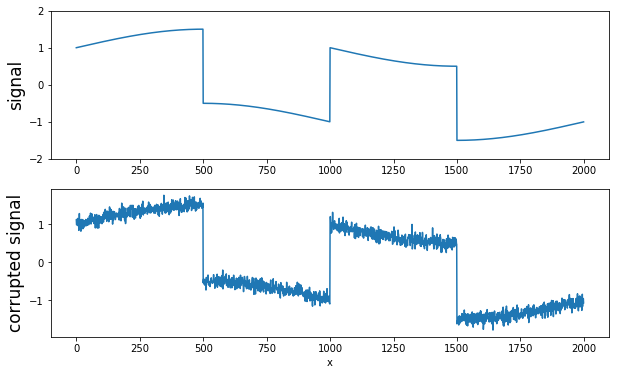

```python
plt.figure(figsize=(10, 6))

plt.subplot(2,1,1)
plt.plot(t, x)
plt.ylim([-2.0,2.0])
plt.ylabel('signal', fontsize = 17)

plt.subplot(2,1,2)
plt.plot(t, x_cor)
plt.ylabel('corrupted signal' , fontsize = 17)
plt.xlabel('x')
plt.show()
```

## Quadratic Smoothing ($L_2$ norm)

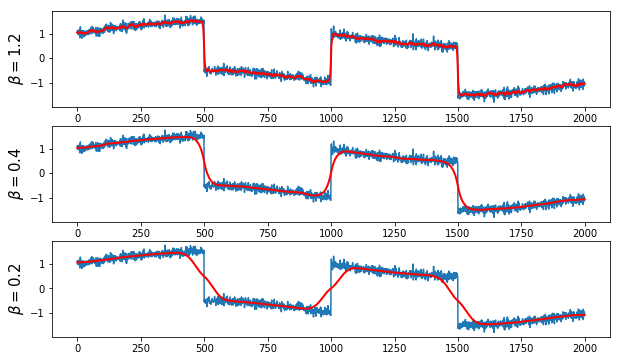

```python
plt.figure(figsize=(10, 6))

beta = [1.2, 0.4, 0.2]

for i in range(len(beta)):
    x_reconst = cvx.Variable(n)
    obj = cvx.Minimize(cvx.norm(x_reconst-x_cor, 2))
    const = [cvx.norm(x_reconst[1:n] - x_reconst[0:n-1], 2) <= beta[i]]
    prob = cvx.Problem(obj, const).solve('SCS')

    plt.subplot(len(beta), 1, i+1)
    plt.plot(t, x_cor)
    plt.plot(t, x_reconst.value, 'r', linewidth=2)
    plt.ylabel(r'$\beta = {}$'.format(beta[i]), fontsize=15)

plt.show()
```

- Quadratic smoothing smooths out *noise and sharp transitions* in signal, but this is not what we want
- Any ideas ?

## $L_1$ Norm

We can instead apply total variation reconstruction on the signal by solving

$$\min \; \lVert x - x_{cor} \rVert_2 + \lambda \sum_{i=1}^{n-1} \;\lvert x_{i+1}-x_i \rvert $$

where the parameter lambda controls the ''smoothness'' of $x$.

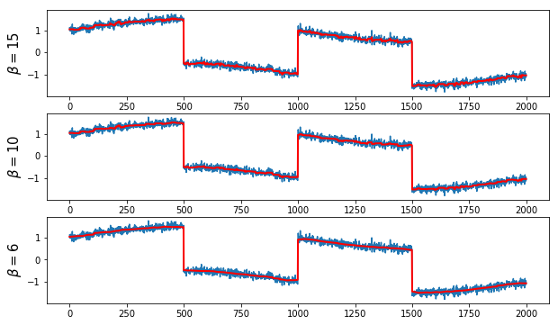

```python
plt.figure(figsize=(10, 6))

beta = [15, 10, 6]

for i in range(len(beta)):
    x_reconst = cvx.Variable(n)
    obj = cvx.Minimize(cvx.norm(x_reconst-x_cor, 2))
    const = [cvx.norm(x_reconst[1:n] - x_reconst[0:n-1], 1) <= beta[i]]
    prob = cvx.Problem(obj, const).solve('SCS')

    plt.subplot(len(beta), 1, i+1)
    plt.plot(t, x_cor)
    plt.plot(t, x_reconst.value, 'r', linewidth=2)
    plt.ylabel(r'$\beta = {}$'.format(beta[i]), fontsize=15)

plt.show()
```

- Total Variation (TV) smoothing preserves sharp transitions in signal, and this is not bad
- Note how TV reconstruction does a better job of preserving the sharp transitions in the signal while removing the noise.

# 3. Total Variation Image Reconstruction

- idea comes from [here](http://www2.compute.dtu.dk/~pcha/mxTV/)

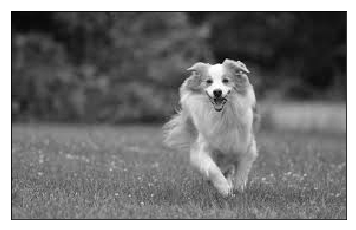

```python
import scipy as sc

imbw = sc.misc.imread('./image_files/dog.jpg','L')
plt.imshow(imbw,'gray')
plt.xticks([])
plt.yticks([])
plt.show()
```

- Question: Apply $L_1$ norm to image, and guess what kind of an image will be produced ?

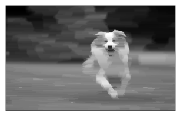

```python
row, col = imbw.shape
n = row * col

imbws = imbw.reshape(-1, 1)

beta = 50000

x = cvx.Variable(n)
obj = cvx.Minimize(cvx.norm(x-imbws,2))
const = [cvx.norm(x[1:n] - x[0:n-1],1) <= beta]
prob = cvx.Problem(obj, const).solve('SCS')

imbwr = x.value.reshape(row, col)

plt.imshow(imbwr,'gray')
plt.xticks([])
plt.yticks([])
plt.show()
```

- Cartoonish effect

```python
%%javascript
$.getScript('https://kmahelona.github.io/ipython_notebook_goodies/ipython_notebook_toc.js')
```